# Serology Data Exploration March 2022

## Datasets

Setup dependancies

```r
library(dplyr)
library(tibble)
library("tidyr")
library(ggplot2)
require(scales)
library(remotes)
#remotes::install_github("Public-Health-Scotland/phsstyles",
##  upgrade = "never"
#)
```

```r
library(phsstyles)
```

### Vaccinations

Vaccinations that include the time, for those who have had a serology sample taken

```r
df_vacc <- readRDS("/conf/EAVE/GPanalysis/data/temp/sero_vacc_time.rds") %>% as_tibble()
nrow(df_vacc)
```

```
[1] 78473
```

### Serology Primary Care

Load serology Primary Care and print the number of rows of data there are. Also, extract the IgG quantative result as a number.

```r
df_serology_pc <- readRDS("/conf/EAVE/GPanalysis/data/serology_primcare_march22.rds") %>%
                  as_tibble() %>%
                  dplyr::mutate(IgG = readr::parse_number(test_result_quant))
nrow(df_serology_pc)
```

```
[1] 59091
```

See the column names…

```r
colnames(df_serology_pc)
```

```
 [1] "EAVE_LINKNO"       "LabSpecimenNo"     "Sampledate_iso"    "year"              "isoweek"           "sex"
 [7] "age"               "healthboard"       "SpecimenOrigin"    "DateCollected"     "EcossDateReceived" "SpecimenDate"
[13] "SpecimenTypeRaw"   "SpecimenType"      "SpecLevel2Group"   "SpecLevel1Group"   "OrganismRaw"       "Type"
[19] "OriginalOrganism"  "test_result_qual"  "test_result_quant" "QNum"              "Text"              "IgG"
```

Make a quick histogram plot of the number of samples collected over time

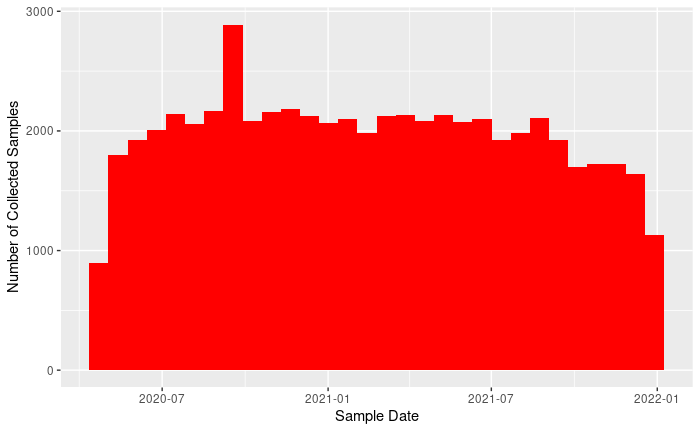

```r
qplot(df_serology_pc$Sampledate_iso, geom="histogram", fill=I("red"), xlab='Sample Date', ylab='Number of Collected Samples', bins=30)
```

Count how many times each person has had a sample taken, and then count how many occurrences there are of people with `nsamples`

```r
df_serology_pc %>% dplyr::group_by(EAVE_LINKNO) %>% dplyr::summarise(nsamples = dplyr::n()) %>%
                   dplyr::group_by(nsamples) %>% dplyr::summarise(noccurrences = dplyr::n())
```

| nsamples | noccurrences |
| --- | --- |
| 1 | 52414 |
| 2 | 2384 |
| 3 | 315 |
| 4 | 110 |
| 5 | 36 |
| 6 | 15 |
| 7 | 9 |
| 8 | 3 |
| 9 | 5 |
| 10 | 3 |

[output cut: 6 more lines]

Filter the dataframe to get the number of rows where there has been a positive test result

```r
df_serology_pc_pos <- df_serology_pc %>% dplyr::filter(test_result_qual == "Positive")
nrow(df_serology_pc_pos)
```

```
[1] 20439
```

### Serology SNBTS (blood donors)

```r
df_serology_bd <- readRDS("/conf/EAVE/GPanalysis/data/serology_snbts_march22.rds") %>%
                  as_tibble() %>%
                  dplyr::mutate(IgG = readr::parse_number(test_result_quant))
```

```
1 parsing failure.
  row col expected actual
24758  -- a number   SKIP
```

```r
nrow(df_serology_bd)
```

```
[1] 39772
```

```r
library(phsstyles)
```

Plot the number of samples collected over time for the blood donors

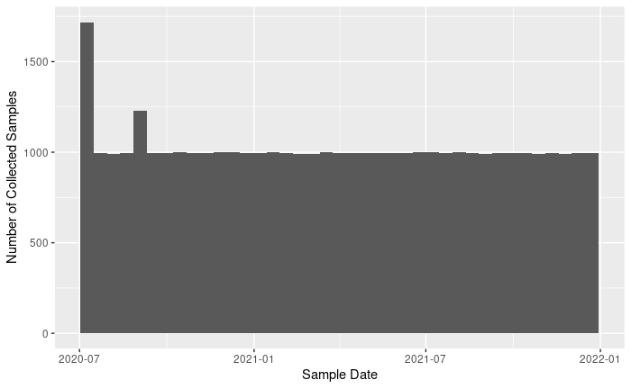

```r
qplot(df_serology_bd$Sampledate_iso,
      geom="histogram",
      xlab='Sample Date', ylab='Number of Collected Samples', bins=40) + scale_colour_discrete_phs(palette = "main")
```

Again, filter the dataframe to get the number of rows where there has been a positive test result:

```r
df_serology_bd_pos <- df_serology_bd %>% dplyr::filter(test_result_qual == "Positive")
nrow(df_serology_bd_pos)
```

```
[1] 18478
```

Check the number of repeat measurements of a person..

```r
df_serology_bd %>% dplyr::group_by(EAVE_LINKNO) %>% dplyr::summarise(nsamples = dplyr::n()) %>%
                   dplyr::group_by(nsamples) %>% dplyr::summarise(noccurrences = dplyr::n())
```

| nsamples | noccurrences |
| --- | --- |
| 1 | 24825 |
| 2 | 5358 |
| 3 | 1122 |
| 4 | 176 |
| 5 | 26 |
| 6 | 4 |
| 7 | 1 |

### QCOVID (Feb22 Update)

Here we load the QCOVID dataframe and filter it on those EAVE studies that are present in the serology datasets.

```r
df_qcovid <- readRDS("/conf/EAVE/GPanalysis/data/cleaned_data/QCOVID_feb22.rds") %>%
             as_tibble()
df_qcovid_pc <- df_qcovid %>% dplyr::filter(EAVE_LINKNO %in% df_serology_pc$EAVE_LINKNO)
nrow(df_qcovid_pc)
```

```
[1] 46489
```

```r
df_qcovid_bd <- df_qcovid %>% dplyr::filter(EAVE_LINKNO %in% df_serology_bd$EAVE_LINKNO)
nrow(df_qcovid_bd)
```

```
[1] 23210
```

```r
df_ana_pc <- df_serology_pc %>% dplyr::left_join(df_qcovid_pc) %>%
          dplyr::select(c("EAVE_LINKNO","Sampledate_iso","test_result_qual","IgG","n_risk_gps")) %>%
          dplyr::mutate(n_risk_gps = ifelse(is.na(n_risk_gps), "0", levels(n_risk_gps)[n_risk_gps]))
df_ana_pc_pos <- df_ana_pc %>% dplyr::filter(test_result_qual == "Positive")
nrow(df_ana_pc_pos)
```

```
[1] 20439
```

```r
df_ana_pc %>% group_by(n_risk_gps) %>% summarise(counts=n())
```

| n_risk_gps | counts |
| --- | --- |
| 0 | 24706 |
| 1 | 20602 |
| 2 | 8430 |
| 3-4 | 4523 |
| 5+ | 830 |

Plot a histogram showing the linking of the serology data (primary care) with QCOVID

```r
colnames(df_ana_pc)
```

```
[1] "EAVE_LINKNO"      "Sampledate_iso"   "test_result_qual" "IgG"              "n_risk_gps"
```

```r
colors <- c("Negative" = phs_colours(c("phs-blue")),"Equivocal" = phs_colours(c("phs-magenta")),"Positive" = phs_colours(c("phs-purple")))
colors
```

```
 Negative Equivocal  Positive
"#0078D4" "#9B4393" "#3F3685"
```

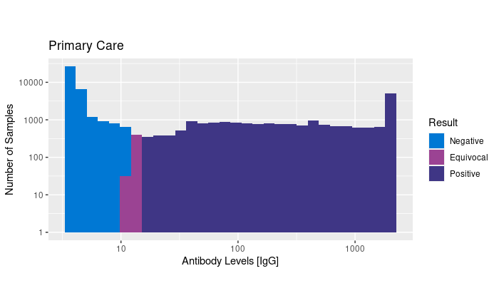

```r
n <- nrow(df_ana_pc)
colors <- c("Negative" = phs_colours(c("phs-blue")),"Equivocal" = phs_colours(c("phs-magenta")),"Positive" = phs_colours(c("phs-purple")))
p <- ggplot(df_ana_pc, aes(x=IgG)) +
     geom_histogram(position = "stack", bins=30, data=subset(df_ana_pc,test_result_qual == 'Negative'), aes(fill='Negative')) +
     geom_histogram(position = "stack", bins=30, data=subset(df_ana_pc,test_result_qual == 'Positive'), aes(fill='Positive')) +
     geom_histogram(position = "stack", bins=30, data=subset(df_ana_pc,test_result_qual == 'Equivocal'), aes(fill='Equivocal')) +
     labs(title='Primary Care',x="Antibody Levels [IgG]", y="Number of Samples", fill="Result") +
     scale_fill_manual(values = colors) +
     theme(aspect.ratio = 0.5)  +
     scale_y_log10() +
     scale_x_log10()
p
```

```r
n <- nrow(df_ana_pc)
p <- ggplot(df_ana_pc, aes(x=IgG, fill=test_result_qual)) +
     geom_histogram(position = "stack", bins=30) +
     labs(title='Primary Care',x="Antibody Levels [IgG]", y="Number of Samples") +
     theme(aspect.ratio = 0.5)  +
     scale_y_log10() +
     scale_x_log10()
p
```

[output not shown]

```r
bw <- 50
n <- nrow(df_ana_pc)
p <- ggplot(df_ana_pc, aes(IgG)) +
     geom_histogram(bins=20) +
     labs(x="Primary Care IgG", y="Number of Samples", fill="Number of Risks (QCOVID)") +
     scale_fill_discrete_phs(palette = "main") +
     theme(aspect.ratio = 0.5)
p
```

[output not shown]

```r
df_ana <- df_ana_pc %>% left_join(df_vacc %>% filter(serology_source=='primary_care_serology'))
```

Measurements taken after 1st Vac, before 2nd Vac

```r
df_ana_v1 <- df_ana %>% filter(Sampledate_iso > d1_datetime & Sampledate_iso < d2_datetime )
```

```r
library(lubridate)
```

```r
# create breaks
breaks <- hour(hm("00:00", "6:00", "12:00", "18:00", "23:59"))
# labels for the breaks
labels <- c("Night", "Morning", "Afternoon", "Evening")

df_ana_v1$Time_of_day <- cut(x=hour(df_ana_v1$d1_datetime), breaks = breaks, labels = labels, include.lowest=TRUE)
```

Calculate the number of days the measurement was taken after the first vaccine

```r
df_ana_v1 <- df_ana_v1 %>% mutate(days_passed = as.numeric(Sampledate_iso - d1_datetime,units='days'))
```

```r
ggplot(df_ana_v1, aes(x=days_passed)) +
  geom_histogram()
```

[output not shown]

```r
ggplot(df_ana_v1, aes(x=IgG)) +
  geom_histogram()
```

[output not shown]

```r
ggplot(df_ana_v1, aes(x=days_passed, y=mean(IgG))) +
  geom_boxplot(width=500)
```

[output not shown]

```r
bin_size <- 20

df_ana_v1 %>%
  mutate(bin_dist = factor(days_passed%/%bin_size)) %>%
  ggplot(aes(x = bin_dist, y = IgG)) +
  geom_boxplot()
```

[output not shown]

```r
df_ana_v1 %>% select(c("Sampledate_iso","IgG","n_risk_gps","d1_product","d1_datetime","Time_of_day","days_passed")) %>% write.csv('test.csv')
```

Plot a histogram showing the linking of the serology data with QCOVID

```r
df_ana_bd <- df_serology_bd %>% dplyr::left_join(df_qcovid_bd) %>%
          dplyr::select(c("EAVE_LINKNO","Sampledate_iso","test_result_qual","IgG","n_risk_gps")) %>%
          dplyr::mutate(n_risk_gps = ifelse(is.na(n_risk_gps), "0", levels(n_risk_gps)[n_risk_gps]))
df_ana_bd_pos <- df_ana_bd %>% dplyr::filter(test_result_qual == "Positive")
```

```r
min(df_ana_bd_pos$IgG)
max(df_ana_bd_pos$IgG)
```

[output not shown]

Number of risk groups in the dataset

```r
df_ana_bd %>% group_by(n_risk_gps) %>% summarise(n=n())
```

[output not shown]

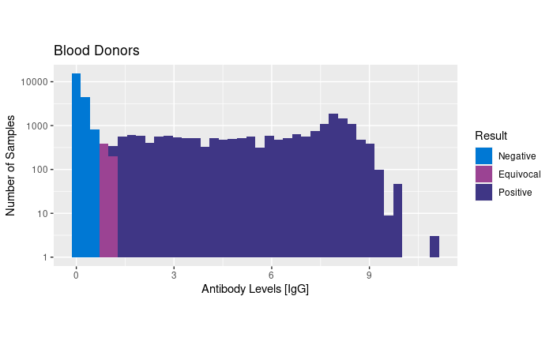

```r
n <- nrow(df_ana_bd)
colors <- c("Negative" = phs_colours(c("phs-blue")),"Equivocal" = phs_colours(c("phs-magenta")),"Positive" = phs_colours(c("phs-purple")))
p <- ggplot(df_ana_bd, aes(x=IgG)) +
     geom_histogram(position = "stack", bins=40, data=subset(df_ana_bd,test_result_qual == 'Negative'), aes(fill='Negative')) +
     geom_histogram(position = "stack", bins=40, data=subset(df_ana_bd,test_result_qual == 'Positive'), aes(fill='Positive')) +
     geom_histogram(position = "stack", bins=40, data=subset(df_ana_bd,test_result_qual == 'Equivocal'), aes(fill='Equivocal')) +
     labs(title='Blood Donors',x="Antibody Levels [IgG]", y="Number of Samples", fill="Result") +
     scale_fill_manual(values = colors) +
     theme(aspect.ratio = 0.5)  +
     scale_y_log10()
p
```

All data

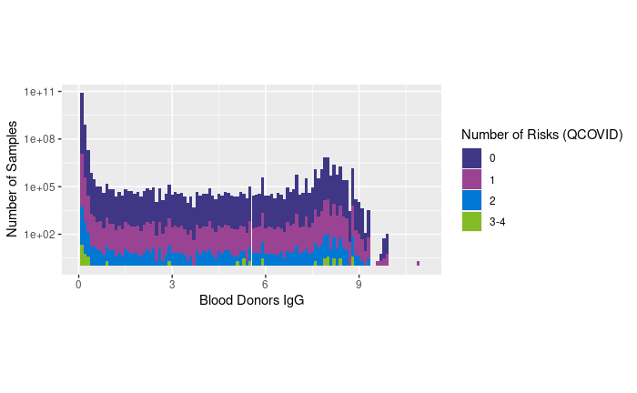

```r
bw <- 0.1
n <- nrow(df_ana_bd)
p <- ggplot(df_ana_bd, aes(x=IgG, fill=n_risk_gps)) +
     geom_histogram(binwidth = bw) + xlim(0,11+bw) +
     labs(x="Blood Donors IgG", y="Number of Samples", fill="Number of Risks (QCOVID)") +
     scale_fill_discrete_phs(palette = "main") +
     scale_y_log10() +
     theme(aspect.ratio = 0.5)
p
```

Positive samples only…

```r
df_ana_bd_pos %>% group_by(n_risk_gps) %>% summarise(n=n())
```

[output not shown]

```r
bw <- 0.1
n <- nrow(df_ana_bd_pos)
p <- ggplot(df_ana_bd_pos, aes(x=IgG, fill=n_risk_gps)) +
     geom_histogram(binwidth = bw) + xlim(0,11+bw) +
     labs(x="Blood Donors IgG", y="Number of Samples", fill="Number of Risks (QCOVID)") +
     scale_fill_discrete_phs(palette = "main") +
     scale_y_log10() +
     theme(aspect.ratio = 0.5)
p
```

[output not shown]